# Akanksha_Dhall_CV

```python
from google.colab import drive
drive.mount('/content/drive',force_remount=True)
```

```python
from PIL import Image
import numpy as np
import matplotlib.pyplot as plt
import tensorflow
from tensorflow.keras.callbacks import ModelCheckpoint, EarlyStopping, ReduceLROnPlateau
from tensorflow.keras.optimizers import Adam
from tensorflow.keras.losses import binary_crossentropy
from tensorflow.keras.applications.mobilenet import MobileNet
from tensorflow.keras.layers import Concatenate, Conv2D, Reshape, UpSampling2D
from tensorflow.keras.models import Model
from matplotlib.patches import Rectangle
from tensorflow.keras.applications.mobilenet import preprocess_input
import cv2
```

**Import and Understand the data**

**1.A Import and read ‘images.npy’.**

```python
image_arr = np.load('/content/drive/MyDrive/AIML/Projects/opencv/opencv/images.npy',allow_pickle=True)
```

**1.B Split the data into Features(X) & labels(Y). Unify shape of all the images**

```python
image_arr.shape
```

```
(409, 2)
```

```python
image_arr[1]
```

```
array([array([[[207, 216, 227, 255],
               [206, 216, 227, 255],
               [207, 216, 227, 255],
               ...,
               [ 35,  33,  34, 255],
               [ 35,  33,  34, 255],
               [ 35,  33,  34, 255]],

              [[207, 216, 227, 255],
               [207, 216, 227, 255],
               [207, 216, 227, 255],
               ...,
               [ 35,  32,  33, 255],
               [ 35,  33,  34, 255],
               [ 35,  33,  34, 255]],

              [[207, 216, 227, 255],
               [207, 216, 227, 255],
               [207, 215, 227, 255],
               ...,
               [ 35,  33,  33, 255],
               [ 35,  33,  34, 255],
               [ 35,  33,  34, 255]],

              ...,

              [[ 31,  21,  17, 255],
               [ 31,  22,  18, 255],
               [ 31,  22,  18, 255],
               ...,
               [  0,   1,   4, 255],
               [  0,   1,   4, 255],
               [  0,   1,   4, 255]],

              [[ 31,  22,  18, 255],
               [ 31,  22,  18, 255],
               [ 31,  22,  18, 255],
               ...,
               [  0,   1,   4, 255],
               [  0,   1,   4, 255],
               [  0,   1,   4, 255]],

              [[ 31,  22,  18, 255],
               [ 30,  22,  17, 255],
               [ 31,  22,  18, 255],
               ...,
               [  0,   1,   4, 255],
               [  0,   1,   4, 255],
               [  0,   1,   4, 255]]], dtype=uint8),
       list([{'label': ['Face'], 'notes': '', 'points': [{'x': 0.7053087757313109, 'y': 0.23260437375745527}, {'x': 0.7692307692307693, 'y': 0.36182902584493043}], 'imageWidth': 1280, 'imageHeight': 697}])],
      dtype=object)
```

```python
image_arr[1][0]
```

```
array([[[207, 216, 227, 255],
        [206, 216, 227, 255],
        [207, 216, 227, 255],
        ...,
        [ 35,  33,  34, 255],
        [ 35,  33,  34, 255],
        [ 35,  33,  34, 255]],

       [[207, 216, 227, 255],
        [207, 216, 227, 255],
        [207, 216, 227, 255],
        ...,
        [ 35,  32,  33, 255],
        [ 35,  33,  34, 255],
        [ 35,  33,  34, 255]],

       [[207, 216, 227, 255],
        [207, 216, 227, 255],
        [207, 215, 227, 255],
        ...,
        [ 35,  33,  33, 255],
        [ 35,  33,  34, 255],
        [ 35,  33,  34, 255]],

       ...,

       [[ 31,  21,  17, 255],
        [ 31,  22,  18, 255],
        [ 31,  22,  18, 255],
        ...,
        [  0,   1,   4, 255],
        [  0,   1,   4, 255],
        [  0,   1,   4, 255]],

       [[ 31,  22,  18, 255],
        [ 31,  22,  18, 255],
        [ 31,  22,  18, 255],
        ...,
        [  0,   1,   4, 255],
        [  0,   1,   4, 255],
        [  0,   1,   4, 255]],

       [[ 31,  22,  18, 255],
        [ 30,  22,  17, 255],
        [ 31,  22,  18, 255],
        ...,
        [  0,   1,   4, 255],
        [  0,   1,   4, 255],
        [  0,   1,   4, 255]]], dtype=uint8)
```

```python
image_arr[90][1]
```

```
[{'label': ['Face'],
  'notes': '',
  'points': [{'x': 0.3422982885085575, 'y': 0.24648469809760132},
   {'x': 0.634881825590872, 'y': 0.5798180314309347}],
  'imageWidth': 2741,
  'imageHeight': 2700}]
```

There are 2 columns. First column contains arrays of array, 3D data. As per the objective of the problem,image 3d Data will falls under feature category.

```python
#feature
X = image_arr[:,0]
#target
Y = image_arr[:,1]
print(X.shape, Y.shape)
```

```
(409,) (409,)
```

```python
print(X[0].shape)
```

```
(333, 650, 3)
```

```python
display(Y[0])
```

```
[{'label': ['Face'],
  'notes': '',
  'points': [{'x': 0.08615384615384615, 'y': 0.3063063063063063},
   {'x': 0.1723076923076923, 'y': 0.45345345345345345}],
  'imageWidth': 650,
  'imageHeight': 333},
 {'label': ['Face'],
  'notes': '',
  'points': [{'x': 0.583076923076923, 'y': 0.2912912912912913},
   {'x': 0.6584615384615384, 'y': 0.46846846846846846}],
  'imageWidth': 650,
  'imageHeight': 333}]
```

**1.C Split the data into train and test[400:9].**

**1.D Select random image from the train data and display original image and masked image.**

Creating mask image

[figure not shown]

```python
plt.imshow(image_arr[0][0])
plt.show()
```

[figure not shown]

```python
masks = np.zeros((int(image_arr.shape[0]), 224, 224))
X = np.zeros((int(image_arr.shape[0]), 224, 224, 3))
index = 0
img = image_arr[index][0]
img = cv2.resize(img, dsize=(224, 224), interpolation=cv2.INTER_CUBIC)

try:
    img = img[:, :, :3]
except:
    pass

X[index] = preprocess_input(np.array(img, dtype=np.float32))

fig, ax = plt.subplots(figsize=(4, 4))
ax.imshow(img)

for i in image_arr[index][1]:
    x1 = int(i["points"][0]['x'] * 224)
    x2 = int(i["points"][1]['x'] * 224)
    y1 = int(i["points"][0]['y'] * 224)
    y2 = int(i["points"][1]['y'] * 224)
    rect = Rectangle((x1, y1), x2 - x1, y2 - y1, linewidth=2, edgecolor='g', facecolor='none')
    ax.add_patch(rect)
    masks[index][y1:y2, x1:x2] = 1

plt.show()
```

**Spliting the data into train and test.**

```python
X = np.zeros((int(image_arr.shape[0]), 224, 224, 3))
for index in range(image_arr.shape[0]):
    img = image_arr[index][0]
    img = cv2.resize(img, dsize=(224, 224), interpolation=cv2.INTER_CUBIC)
    try:
      img = img[:, :, :3]
    except:
      continue
    X[index] = preprocess_input(np.array(img, dtype=np.float32))
    for i in image_arr[index][1]:
        x1 = int(i["points"][0]['x'] * 224)
        x2 = int(i["points"][1]['x'] * 224)
        y1 = int(i["points"][0]['y'] * 224)
        y2 = int(i["points"][1]['y'] * 224)
        masks[index][y1:y2, x1:x2] = 1
```

```python
train_X = X[:400]
train_Y = masks[:400]
test_X = X[400:]
test_Y = masks[400:]
```

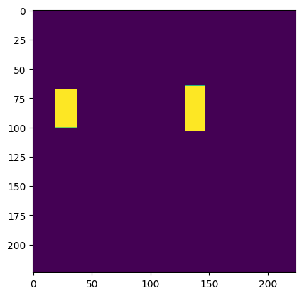

```python
plt.imshow(train_Y[0])
```

**2. Model building**

**2.A Design a face mask detection model**

```python
new_width = 224
new_height = 224
ALPHA=1
```

```python
def create_model(trainable=True):
    model = MobileNet(input_shape=(new_height, new_width, 3), include_top=False, alpha=ALPHA, weights="imagenet")

    for layer in model.layers:
        layer.trainable = trainable

    block1 = model.get_layer("conv_pw_5_relu").output
    block2 = model.get_layer("conv_pw_11_relu").output
    block3 = model.get_layer("conv_pw_13_relu").output

    x = Concatenate()([UpSampling2D()(block3), block2])
    x = Concatenate()([UpSampling2D()(x), block1])

    x = Conv2D(1, kernel_size=1, activation="sigmoid")(x)
    x = UpSampling2D(size=(new_height // x.shape[1], new_width // x.shape[2]))(x)

    return Model(inputs=model.input, outputs=x)
```

```python
model = create_model()
model.summary()
```

```
Model: "model"
__________________________________________________________________________________________________
 Layer (type)                Output Shape                 Param #   Connected to
==================================================================================================
 input_1 (InputLayer)        [(None, 224, 224, 3)]        0         []

 conv1 (Conv2D)              (None, 112, 112, 32)         864       ['input_1[0][0]']

 conv1_bn (BatchNormalizati  (None, 112, 112, 32)         128       ['conv1[0][0]']
 on)

 conv1_relu (ReLU)           (None, 112, 112, 32)         0         ['conv1_bn[0][0]']

 conv_dw_1 (DepthwiseConv2D  (None, 112, 112, 32)         288       ['conv1_relu[0][0]']
 )

 conv_dw_1_bn (BatchNormali  (None, 112, 112, 32)         128       ['conv_dw_1[0][0]']
 zation)

 conv_dw_1_relu (ReLU)       (None, 112, 112, 32)         0         ['conv_dw_1_bn[0][0]']

 conv_pw_1 (Conv2D)          (None, 112, 112, 64)         2048      ['conv_dw_1_relu[0][0]']

 conv_pw_1_bn (BatchNormali  (None, 112, 112, 64)         256       ['conv_pw_1[0][0]']
 zation)

 conv_pw_1_relu (ReLU)       (None, 112, 112, 64)         0         ['conv_pw_1_bn[0][0]']

 conv_pad_2 (ZeroPadding2D)  (None, 113, 113, 64)         0         ['conv_pw_1_relu[0][0]']

 conv_dw_2 (DepthwiseConv2D  (None, 56, 56, 64)           576       ['conv_pad_2[0][0]']
 )

 conv_dw_2_bn (BatchNormali  (None, 56, 56, 64)           256       ['conv_dw_2[0][0]']
 zation)

 conv_dw_2_relu (ReLU)       (None, 56, 56, 64)           0         ['conv_dw_2_bn[0][0]']

 conv_pw_2 (Conv2D)          (None, 56, 56, 128)          8192      ['conv_dw_2_relu[0][0]']

```

[output cut: 184 more lines]

```
 g2D)

 concatenate_1 (Concatenate  (None, 28, 28, 1792)         0         ['up_sampling2d_1[0][0]',
 )                                                                   'conv_pw_5_relu[0][0]']

 conv2d (Conv2D)             (None, 28, 28, 1)            1793      ['concatenate_1[0][0]']

 up_sampling2d_2 (UpSamplin  (None, 224, 224, 1)          0         ['conv2d[0][0]']
 g2D)

==================================================================================================
Total params: 3230657 (12.32 MB)
Trainable params: 3208769 (12.24 MB)
Non-trainable params: 21888 (85.50 KB)
__________________________________________________________________________________________________
```

**2.B Design your own Dice Coefficient and Loss function.**

```python
def loss(y_true, y_pred):
    return binary_crossentropy(y_true, y_pred) - tensorflow.keras.backend.log(dice_coefficient(y_true, y_pred) + tensorflow.keras.backend.epsilon())
```

```python
def dice_coefficient(y_true, y_pred):
    numerator = 2 * tensorflow.reduce_sum(y_true * y_pred)
    denominator = tensorflow.reduce_sum(y_true + y_pred)
    return numerator / (denominator + tensorflow.keras.backend.epsilon())
```

```python
optimizer = Adam(learning_rate=1e-2)
model.compile(loss=loss, optimizer=optimizer, metrics=[dice_coefficient])
```

```python
checkpoint = ModelCheckpoint("model-{val_loss:.2f}.h5", monitor="val_loss", verbose=1, save_best_only=True, save_weights_only=True)
stop = EarlyStopping(monitor="val_loss", patience=5)
reduce_lr = ReduceLROnPlateau(monitor="val_loss", factor=0.2, patience=5, min_lr=1e-6, verbose=1)
```

**2.C Train and tune the model as required**

```python
model.fit(train_X, train_Y, epochs=10, verbose=2)
```

```
13/13 - 97s - loss: 2.2515 - dice_coefficient: 0.4298 - 97s/epoch - 7s/step
13/13 - 81s - loss: 1.0778 - dice_coefficient: 0.5380 - 81s/epoch - 6s/step
13/13 - 89s - loss: 0.7876 - dice_coefficient: 0.6052 - 89s/epoch - 7s/step
13/13 - 82s - loss: 0.6644 - dice_coefficient: 0.6544 - 82s/epoch - 6s/step
13/13 - 82s - loss: 0.5736 - dice_coefficient: 0.6913 - 82s/epoch - 6s/step
13/13 - 89s - loss: 0.4903 - dice_coefficient: 0.7300 - 89s/epoch - 7s/step
13/13 - 83s - loss: 0.4556 - dice_coefficient: 0.7486 - 83s/epoch - 6s/step
13/13 - 83s - loss: 0.4672 - dice_coefficient: 0.7534 - 83s/epoch - 6s/step
13/13 - 83s - loss: 0.4398 - dice_coefficient: 0.7529 - 83s/epoch - 6s/step
13/13 - 83s - loss: 0.3863 - dice_coefficient: 0.7855 - 83s/epoch - 6s/step
```

```
<keras.src.callbacks.History at 0x7ed76509e740>
```

**2.D Evaluate and share insights on performance of the model**

```python
accuracy_train = model.evaluate(train_X, train_Y, verbose=2)
print("Accuracy_train", accuracy_train)
print("**********************************")
accuracy_test = model.evaluate(test_X, test_Y, verbose=2)
print("Accuracy_test", accuracy_test)
```

```
13/13 - 18s - loss: 1.1928 - dice_coefficient: 0.5614 - 18s/epoch - 1s/step
Accuracy_train [1.1927862167358398, 0.5614023804664612]
1/1 - 0s - loss: 1.2663 - dice_coefficient: 0.5352 - 313ms/epoch - 313ms/step
Accuracy_test [1.266276240348816, 0.5352243185043335]
```

For epoch 10, losson test data is 1.26 and dice_coefficient is .53 For Epoch - 40,the loss on test data was around .40 and dice -coefficient was around .73. (My google colab was crashing this time for epoch = 40)

**2.E Test the model predictions on the test image: ‘image with index 3 in the test data’ and visualise the predicted masks on the faces in the image**

```
WARNING:matplotlib.image:Clipping input data to the valid range for imshow with RGB data ([0..1] for floats or [0..255] for integers).
```

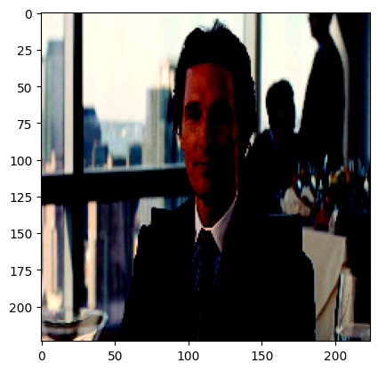

```python
n=3
plt.imshow(test_X[3], alpha=1)
```

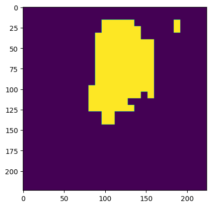

```python
predicted_mask = model.predict(x=np.array([test_X[n]]))[0]
thresholded_mask = (predicted_mask > 0.7).astype(np.float32)
resized_mask = cv2.resize(thresholded_mask, (224, 224))
plt.imshow(resized_mask, alpha=1)
```

**Part -B**

**1. Read/import images from folder ‘training_images’.**

```python
import random
from google.colab.patches import cv2_imshow
from zipfile import ZipFile
import cv2
import os
from PIL import Image
from datetime import datetime
import pandas as pd
```

```python
# training_images='/content/drive/MyDrive/AIML/Projects/opencv/opencv/training_images-20211126T092819Z-001.zip'
# with ZipFile(training_images,'r') as zip:
#   zip.extractall('/content/drive/MyDrive/AIML/Projects/opencv/opencv')
```

**2. Write a loop which will iterate through all the images in the ‘training_images’ folder and detect the faces present on all the images**

```python
face_cascade = cv2.CascadeClassifier(cv2.data.haarcascades + 'haarcascade_frontalface_default.xml')
folder_path= '/content/drive/MyDrive/AIML/Projects/opencv/opencv/training_images'
image_filenames = [filename for filename in os.listdir(folder_path) if filename.endswith(('.jpg', '.jpeg', '.png', '.gif'))]
for filename in image_filenames:
    image_path = os.path.join(folder_path, filename)
    img = cv2.imread(image_path)
    gray = cv2.cvtColor(img, cv2.COLOR_BGR2GRAY)
    faces = face_cascade.detectMultiScale(gray, scaleFactor=1.3, minNeighbors=5, minSize=(30, 30))
    for (x, y, w, h) in faces:
        cv2.rectangle(img, (x, y), (x+w, y+h), (255, 0, 0), 2)
    #cv2_imshow(img) commented the step , it will increase the size of the file.
```

**3. From the same loop above, extract metadata of the faces and write into a DataFrame**

```python
face_cascade = cv2.CascadeClassifier(cv2.data.haarcascades + 'haarcascade_frontalface_default.xml')

folder_path = '/content/drive/MyDrive/AIML/Projects/opencv/opencv/training_images'
face_metadata_list = []
for filename in os.listdir(folder_path):
    if filename.endswith(('.jpg', '.jpeg', '.png', '.gif')):
        image_path = os.path.join(folder_path, filename)
        img = cv2.imread(image_path)
        gray = cv2.cvtColor(img, cv2.COLOR_BGR2GRAY)
        faces = face_cascade.detectMultiScale(gray, scaleFactor=1.3, minNeighbors=5, minSize=(30, 30))
        for i, (x, y, w, h) in enumerate(faces, start=1):
            face_metadata_list.append({
                'X': x,
                'Y': y,
                'Width': w,
                'Height': h,
                'Total_Faces':i,
                'Image_Name':filename
                            })
face_metadata_df = pd.DataFrame(face_metadata_list)
print("Face Metadata:")
print(face_metadata_df)
```

```
Face Metadata:
       X    Y  Width  Height  Total_Faces      Image_Name
0     86  134    397     397            1  real_00908.jpg
1    118  181    376     376            1  real_00889.jpg
2    129  260    331     331            1  real_00923.jpg
3    143   81    430     430            1  real_00828.jpg
4    132  192    345     345            1  real_00817.jpg
..   ...  ...    ...     ...          ...             ...
689   54   56    483     483            1  real_00812.jpg
690   70  151    397     397            1  real_00810.jpg
691   95  116    440     440            1  real_00858.jpg
692   64   47    476     476            1  real_00833.jpg
693   87  107    425     425            1  real_00933.jpg

[694 rows x 6 columns]
```

**4. Save the output Dataframe in .csv format**

```python
csv_filename = 'face_metadata.csv'
face_metadata_df.to_csv(csv_filename, index=False)
face_metadata_df
```

|  | X | Y | Width | Height | Total_Faces | Image_Name |
| --- | --- | --- | --- | --- | --- | --- |
| 0 | 86 | 134 | 397 | 397 | 1 | real_00908.jpg |
| 1 | 118 | 181 | 376 | 376 | 1 | real_00889.jpg |
| 2 | 129 | 260 | 331 | 331 | 1 | real_00923.jpg |
| 3 | 143 | 81 | 430 | 430 | 1 | real_00828.jpg |
| 4 | 132 | 192 | 345 | 345 | 1 | real_00817.jpg |
| ... | ... | ... | ... | ... | ... | ... |
| 689 | 54 | 56 | 483 | 483 | 1 | real_00812.jpg |
| 690 | 70 | 151 | 397 | 397 | 1 | real_00810.jpg |
| 691 | 95 | 116 | 440 | 440 | 1 | real_00858.jpg |
| 692 | 64 | 47 | 476 | 476 | 1 | real_00833.jpg |
| 693 | 87 | 107 | 425 | 425 | 1 | real_00933.jpg |

694 rows × 6 columns

**Part C -**

**1. Unzip, read and Load data(‘PINS.zip’) into session**

```python
import numpy as np
import os
import cv2
from tensorflow.keras.models import Sequential
from tensorflow.keras.layers import ZeroPadding2D, Convolution2D, MaxPooling2D, Dropout, Flatten, Activation
from tensorflow.keras.models import model_from_json
from sklearn.preprocessing import LabelEncoder
from sklearn.preprocessing import StandardScaler
from sklearn.decomposition import PCA
from sklearn.svm import SVC
import warnings
warnings.filterwarnings('ignore')
```

```python
# images_path_pins='/content/drive/MyDrive/AIML/Projects/opencv/opencv/PINS.zip'
# from zipfile import ZipFile
# with ZipFile(images_path_pins,'r') as zip:
#   zip.extractall('/content/drive/MyDrive/AIML/Projects/opencv/opencv/')
```

**2. Write function to create metadata of the image**

```python
class IdentityMetadata():
    def __init__(self, base, name, file):
        # print(base, name, file)
        # dataset base directory
        self.base = base
        # identity name
        self.name = name
        # image file name
        self.file = file

    def __repr__(self):
        return self.image_path()

    def image_path(self):
        return os.path.join(self.base, self.name, self.file)
```

**3. Write a loop to iterate through each and every image and create metadata for all the images**

```python
def load_metadata(path):
    metadata = []
    for i in os.listdir(path):
        for f in os.listdir(os.path.join(path, i)):
            # Check file extension. Allow only jpg/jpeg' files.
            ext = os.path.splitext(f)[1]
            if ext == '.jpg' or ext == '.jpeg':
                metadata.append(IdentityMetadata(path, i, f))
    return np.array(metadata)
```

```python
directory_path = '/content/drive/MyDrive/AIML/Projects/opencv/opencv/PINS'
metadata = load_metadata(directory_path)
print(metadata)
print(type(metadata))
```

```
[/content/drive/MyDrive/AIML/Projects/opencv/opencv/PINS/pins_Chance Perdomo/Chance Perdomo82.jpg
 /content/drive/MyDrive/AIML/Projects/opencv/opencv/PINS/pins_Chance Perdomo/Chance Perdomo2.jpg
 /content/drive/MyDrive/AIML/Projects/opencv/opencv/PINS/pins_Chance Perdomo/Chance Perdomo69.jpg
 ...
 /content/drive/MyDrive/AIML/Projects/opencv/opencv/PINS/pins_shakira/shakira32.jpg
 /content/drive/MyDrive/AIML/Projects/opencv/opencv/PINS/pins_shakira/shakira23.jpg
 /content/drive/MyDrive/AIML/Projects/opencv/opencv/PINS/pins_shakira/shakira40.jpg]
<class 'numpy.ndarray'>
```

```python
def load_image(path):
    img = cv2.imread(path, 1)
    return cv2.cvtColor(img, cv2.COLOR_BGR2RGB)
```

```python
load_image(metadata[0].image_path())
```

```
array([[[ 47,  30,  10],
        [ 46,  29,   9],
        [ 43,  27,  11],
        ...,
        [ 16,   6,   4],
        [ 17,   7,   5],
        [ 20,   9,   7]],

       [[ 46,  29,   9],
        [ 45,  28,  10],
        [ 42,  26,  10],
        ...,
        [ 15,   5,   3],
        [ 16,   6,   4],
        [ 19,   8,   6]],

       [[ 45,  28,  10],
        [ 44,  27,   9],
        [ 41,  25,   9],
        ...,
        [ 15,   5,   3],
        [ 17,   6,   4],
        [ 19,   8,   6]],

       ...,

       [[ 13,   5,   2],
        [ 14,   6,   3],
        [ 12,   7,   3],
        ...,
        [119,  75,  26],
        [119,  75,  26],
        [119,  75,  28]],

       [[ 13,   5,   2],
        [ 13,   5,   2],
        [ 12,   7,   3],
        ...,
        [118,  74,  25],
        [118,  74,  25],
        [118,  74,  27]],

       [[ 11,   6,   0],
        [ 12,   7,   1],
        [ 12,   7,   3],
        ...,
        [118,  74,  25],
        [118,  74,  25],
        [118,  74,  25]]], dtype=uint8)
```

**4. Generate Embeddings vectors on the each face in the dataset**

```python
def vgg_face():
    model = Sequential()
    model.add(ZeroPadding2D((1,1),input_shape=(224,224, 3)))
    model.add(Convolution2D(64, (3, 3), activation='relu'))
    model.add(ZeroPadding2D((1,1)))
    model.add(Convolution2D(64, (3, 3), activation='relu'))
    model.add(MaxPooling2D((2,2), strides=(2,2)))

    model.add(ZeroPadding2D((1,1)))
    model.add(Convolution2D(128, (3, 3), activation='relu'))
    model.add(ZeroPadding2D((1,1)))
    model.add(Convolution2D(128, (3, 3), activation='relu'))
    model.add(MaxPooling2D((2,2), strides=(2,2)))

    model.add(ZeroPadding2D((1,1)))
    model.add(Convolution2D(256, (3, 3), activation='relu'))
    model.add(ZeroPadding2D((1,1)))
    model.add(Convolution2D(256, (3, 3), activation='relu'))
    model.add(ZeroPadding2D((1,1)))
    model.add(Convolution2D(256, (3, 3), activation='relu'))
    model.add(MaxPooling2D((2,2), strides=(2,2)))

    model.add(ZeroPadding2D((1,1)))
    model.add(Convolution2D(512, (3, 3), activation='relu'))
    model.add(ZeroPadding2D((1,1)))
    model.add(Convolution2D(512, (3, 3), activation='relu'))
    model.add(ZeroPadding2D((1,1)))
    model.add(Convolution2D(512, (3, 3), activation='relu'))
    model.add(MaxPooling2D((2,2), strides=(2,2)))

    model.add(ZeroPadding2D((1,1)))
    model.add(Convolution2D(512, (3, 3), activation='relu'))
    model.add(ZeroPadding2D((1,1)))
    model.add(Convolution2D(512, (3, 3), activation='relu'))
    model.add(ZeroPadding2D((1,1)))
    model.add(Convolution2D(512, (3, 3), activation='relu'))
    model.add(MaxPooling2D((2,2), strides=(2,2)))

    model.add(Convolution2D(4096, (7, 7), activation='relu'))
    model.add(Dropout(0.5))
    model.add(Convolution2D(4096, (1, 1), activation='relu'))
    model.add(Dropout(0.5))
    model.add(Convolution2D(2622, (1, 1)))
    model.add(Flatten())
    model.add(Activation('softmax'))
    return model
```

```python
model = vgg_face()
import os
weights_file = '/content/drive/MyDrive/AIML/Projects/opencv/opencv/vgg_face_weights.h5'

if os.path.exists(weights_file):
    model.load_weights(weights_file)
else:
    print("Weights file not found:", weights_file)
```

```python
from tensorflow.keras.models import Model
vgg_face_descriptor = Model(inputs=model.layers[0].input, outputs=model.layers[-2].output)
```

```python
embeddings = np.zeros((metadata.shape[0], 2622))
k = 0
for i, m in enumerate(metadata):
        img = load_image(m.image_path())
        if k % 500 == 0:
            print(k)
        img = cv2.resize(img, dsize = (224,224))
        img = (img / 255.).astype(np.float32)
        embeddings[i] = vgg_face_descriptor.predict(np.expand_dims(img, axis=0))[0]
        k =k+1
```

```
Streaming output truncated to the last 5000 lines.
6000
6500
7000
7500
8000
8500
9000
9500
10000
10500
```

**5. Build distance metrics for identifying the distance between two similar and dissimilar images.**

```python
def distance(emb1, emb2):
    return np.sum(np.square(emb1 - emb2))
```

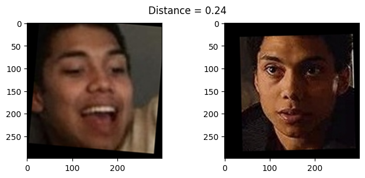

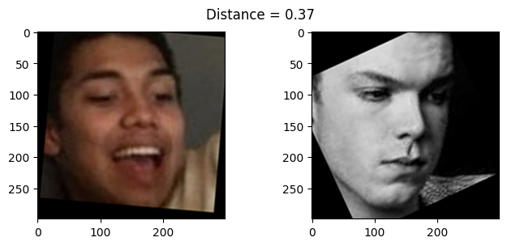

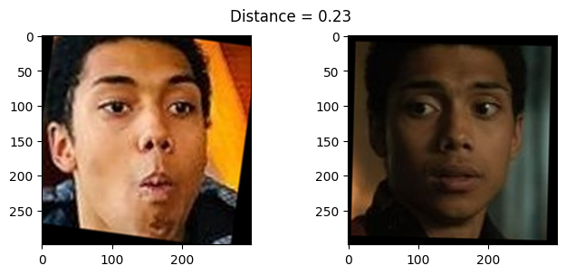

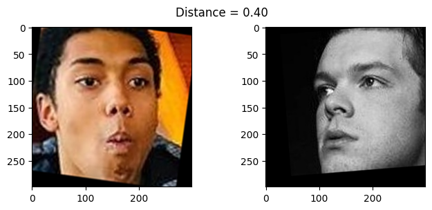

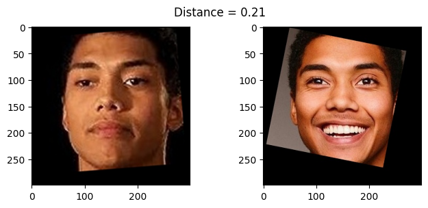

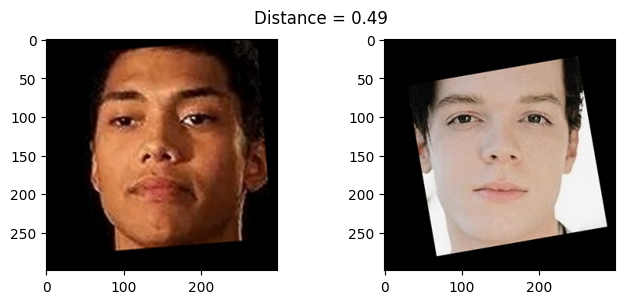

```python
import matplotlib.pyplot as plt

def show_pair(idx1, idx2):
    plt.figure(figsize=(8,3))
    plt.suptitle(f'Distance = {distance(embeddings[idx1], embeddings[idx2]):.2f}')
    plt.subplot(121)
    plt.imshow(load_image(metadata[idx1].image_path()))
    plt.subplot(122)
    plt.imshow(load_image(metadata[idx2].image_path()));

show_pair(2, 3)
show_pair(2,180)
show_pair (30,31)
show_pair(30,100)
show_pair(70,72)
show_pair(70,115)
```

```python
train_idx = np.arange(metadata.shape[0]) % 7 != 0
test_idx = np.arange(metadata.shape[0]) % 7 == 0

X_train = embeddings[train_idx]
X_test = embeddings[test_idx]

targets = np.array([m.name for m in metadata])
y_train = targets[train_idx]
y_test = targets[test_idx]
```

```python
encoder = LabelEncoder()
y_train = encoder.fit_transform(y_train)
y_test = encoder.transform(y_test)
```

```python
sc = StandardScaler()
X_train = sc.fit_transform(X_train)
X_test = sc.transform(X_test)
```

**6. Use PCA for dimensionality reduction**

```python
pca = PCA(n_components=128, svd_solver='randomized', whiten=True)
X_train = pca.fit_transform(X_train)
X_test = pca.transform(X_test)
```

**7.Build an SVM classifier in order to map each image to its right person.**

```python
clf = SVC(kernel='rbf', C=10000000, gamma='auto')
clf.fit(X_train, y_train)
clf.score(X_test, y_test)
```

```
0.9603381014304291
```

**8.Import and display the the test images**

```
/content/drive/MyDrive/AIML/Projects/opencv/opencv/PINS/pins_Cameron Monaghan/Cameron Monaghan69.jpg
```

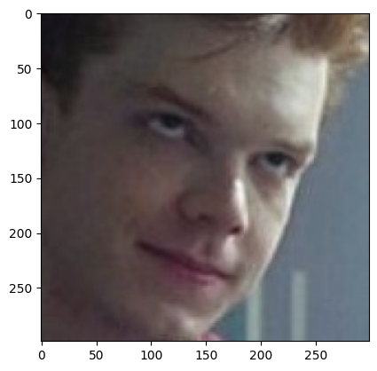

```python
test_image = 23
test_img = load_image(metadata[test_idx][test_image].image_path())
plt.imshow(test_img)
print(metadata[test_idx][test_image].image_path())
```

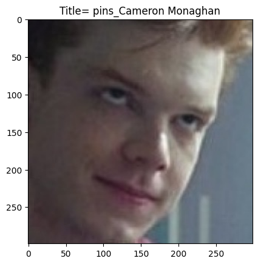

```python
test_img_pred = clf.predict([X_test[test_image]])
img_title = encoder.inverse_transform(test_img_pred)[0]
plt.imshow(test_img)
plt.title(f'Title= {img_title}');
```